# Prediction Assignment Writeup

Guillaume Bonnissent

4 December 2018

## Executive Summary

Using devices such as Jawbone Up, Nike FuelBand, and Fitbit it is now possible to collect a large amount of data about personal activity relatively inexpensively. These type of devices are part of the quantified self movement - a group of enthusiasts who take measurements about themselves regularly to improve their health, to find patterns in their behavior, or because they are tech geeks. One thing that people regularly do is quantify how much of a particular activity they do, but they rarely quantify how well they do it. In this project, your goal will be to use data from accelerometers on the belt, forearm, arm, and dumbell of 6 participants. They were asked to perform barbell lifts correctly and incorrectly in 5 different ways. More information is available from the website here: http://web.archive.org/web/20161224072740/http:/groupware.les.inf.puc-rio.br/har (see the section on the Weight Lifting Exercise Dataset).

The data for this project come from this source: http://web.archive.org/web/20161224072740/http:/groupware.les.inf.puc-rio.br/har.

The goal of our project is to predict the manner in which they did the exercise. This is the “classe” variable in the training set. We will also use our prediction model to predict 20 different test cases.

After some exploraty data analysis and data cleansing, we tested different model and concluded that the random forest method from the caret package with the default settings was the best model.

## Exploratory Data Analysis and Data Selection

```r
# Load the training and test data, and look at their respective structure.
trainingdata <- read.csv('https://d396qusza40orc.cloudfront.net/predmachlearn/pml-training.csv', na.strings = '#DIV/0!', row.names = 1)
testdata <- read.csv('https://d396qusza40orc.cloudfront.net/predmachlearn/pml-testing.csv', na.strings = '#DIV/0!', row.names = 1)
str(trainingdata)
```

```
## 'data.frame':    19622 obs. of  159 variables:
##  $ user_name               : Factor w/ 6 levels "adelmo","carlitos",..: 2 2 2 2 2 2 2 2 2 2 ...
##  $ raw_timestamp_part_1    : int  1323084231 1323084231 1323084231 1323084232 1323084232 1323084232 1323084232 1323084232 1323084232 1323084232 ...
##  $ raw_timestamp_part_2    : int  788290 808298 820366 120339 196328 304277 368296 440390 484323 484434 ...
##  $ cvtd_timestamp          : Factor w/ 20 levels "02/12/2011 13:32",..: 9 9 9 9 9 9 9 9 9 9 ...
##  $ new_window              : Factor w/ 2 levels "no","yes": 1 1 1 1 1 1 1 1 1 1 ...
##  $ num_window              : int  11 11 11 12 12 12 12 12 12 12 ...
##  $ roll_belt               : num  1.41 1.41 1.42 1.48 1.48 1.45 1.42 1.42 1.43 1.45 ...
##  $ pitch_belt              : num  8.07 8.07 8.07 8.05 8.07 8.06 8.09 8.13 8.16 8.17 ...
##  $ yaw_belt                : num  -94.4 -94.4 -94.4 -94.4 -94.4 -94.4 -94.4 -94.4 -94.4 -94.4 ...
##  $ total_accel_belt        : int  3 3 3 3 3 3 3 3 3 3 ...
##  $ kurtosis_roll_belt      : num  NA NA NA NA NA NA NA NA NA NA ...
##  $ kurtosis_picth_belt     : num  NA NA NA NA NA NA NA NA NA NA ...
##  $ kurtosis_yaw_belt       : logi  NA NA NA NA NA NA ...
##  $ skewness_roll_belt      : num  NA NA NA NA NA NA NA NA NA NA ...
```

[output cut: 86 more lines]

```r
str(testdata)
```

```
## 'data.frame':    20 obs. of  159 variables:
##  $ user_name               : Factor w/ 6 levels "adelmo","carlitos",..: 6 5 5 1 4 5 5 5 2 3 ...
##  $ raw_timestamp_part_1    : int  1323095002 1322673067 1322673075 1322832789 1322489635 1322673149 1322673128 1322673076 1323084240 1322837822 ...
##  $ raw_timestamp_part_2    : int  868349 778725 342967 560311 814776 510661 766645 54671 916313 384285 ...
##  $ cvtd_timestamp          : Factor w/ 11 levels "02/12/2011 13:33",..: 5 10 10 1 6 11 11 10 3 2 ...
##  $ new_window              : Factor w/ 1 level "no": 1 1 1 1 1 1 1 1 1 1 ...
##  $ num_window              : int  74 431 439 194 235 504 485 440 323 664 ...
##  $ roll_belt               : num  123 1.02 0.87 125 1.35 -5.92 1.2 0.43 0.93 114 ...
##  $ pitch_belt              : num  27 4.87 1.82 -41.6 3.33 1.59 4.44 4.15 6.72 22.4 ...
##  $ yaw_belt                : num  -4.75 -88.9 -88.5 162 -88.6 -87.7 -87.3 -88.5 -93.7 -13.1 ...
##  $ total_accel_belt        : int  20 4 5 17 3 4 4 4 4 18 ...
##  $ kurtosis_roll_belt      : logi  NA NA NA NA NA NA ...
##  $ kurtosis_picth_belt     : logi  NA NA NA NA NA NA ...
##  $ kurtosis_yaw_belt       : logi  NA NA NA NA NA NA ...
##  $ skewness_roll_belt      : logi  NA NA NA NA NA NA ...
```

[output cut: 86 more lines]

For the sake of clarity, we will explain the nomenclature used during our analysis for the different datasets: - trainingdata is the dataset that will be used to build the model - modeltraining is the dataset that will be used to train the model, and will be made of 60% randomly selected observations from trainingdata - modeltesting is the dataset that will be used to test the model, and will be made of 40% of randomly selected observations from trainingdata - testdata is the dataset that will be used to do a final test of the model, as per the assignment given to us.

For our analysis, we want to use the data from accelerometers on the belt, forearm, arm, and dumbell. The first 6 columns are therefore irrelevant to our analysis, hence we delete them.

```r
trainingdata <- trainingdata[, 7:159]
testdata <- testdata[, 7:159]
```

We can see that some factors have mainly NA values. For our analysis, we want to remove any factor where there is a NA value. For the integrity of the test data, we will remove the same columns on the training and test data.

```r
NAcolumns <- names(trainingdata[, colSums(is.na(trainingdata)) > 0])
trainingdata <- trainingdata[, !(names(trainingdata) %in% NAcolumns)]
testdata <- testdata[, !(names(testdata) %in% NAcolumns)]
```

We partition the data using the caret package, assigning 60% to modeltraining and 40% to modeltesting.

```r
library(caret)
set.seed(1234)
inTrain <- createDataPartition(trainingdata$classe, p = 0.6, list = FALSE)
modeltraining <- trainingdata[inTrain, ]
modeltesting <- trainingdata[-inTrain, ]
```

Again using the caret package, we identify the near zero variance predictors in modeltraining and delete them from all three datasets.

```r
nzv <- nearZeroVar(modeltraining, saveMetrics = TRUE)
modeltraining <- modeltraining[, nzv$nzv == FALSE]
modeltesting <- modeltesting[, nzv$nzv == FALSE]
testdata <- testdata[, nzv$nzv == FALSE]
```

We now have a much reduced list of predictors, as shown below.

```r
dim(modeltraining)
```

```
## [1] 11776    53
```

## Model Building

We decided to run three popular machine learning algorithms with different characteristics: Random Forest, Linear Discriminant Analysis and Gradient Boosting.

```r
library(randomForest)
library(gbm)
set.seed(1234)
modelrf <- train(classe ~ ., modeltraining, method = 'rf')
modellda <- train(classe ~ ., modeltraining, method = 'lda')
modelgbm <- train(classe ~ ., modeltraining, method = 'gbm', verbose = FALSE)
```

### Random Forest Model

```r
predictionrf <- predict(modelrf, modeltesting)
confusionMatrix(predictionrf, modeltesting$classe)
```

```
## Confusion Matrix and Statistics
##
##           Reference
## Prediction    A    B    C    D    E
##          A 2231   18    0    0    0
##          B    0 1493   11    1    2
##          C    1    7 1349   20    2
##          D    0    0    8 1263    5
##          E    0    0    0    2 1433
##
## Overall Statistics
##
##                Accuracy : 0.9902
##                  95% CI : (0.9877, 0.9922)
##     No Information Rate : 0.2845
##     P-Value [Acc > NIR] : < 2.2e-16
##
##                   Kappa : 0.9876
##  Mcnemar's Test P-Value : NA
##
## Statistics by Class:
##
##                      Class: A Class: B Class: C Class: D Class: E
## Sensitivity            0.9996   0.9835   0.9861   0.9821   0.9938
## Specificity            0.9968   0.9978   0.9954   0.9980   0.9997
## Pos Pred Value         0.9920   0.9907   0.9782   0.9898   0.9986
## Neg Pred Value         0.9998   0.9961   0.9971   0.9965   0.9986
## Prevalence             0.2845   0.1935   0.1744   0.1639   0.1838
## Detection Rate         0.2843   0.1903   0.1719   0.1610   0.1826
## Detection Prevalence   0.2866   0.1921   0.1758   0.1626   0.1829
## Balanced Accuracy      0.9982   0.9907   0.9907   0.9901   0.9967
```

### Linear Discriminant Analysis

```r
predictionlda <- predict(modellda, modeltesting)
confusionMatrix(predictionlda, modeltesting$classe)
```

```
## Confusion Matrix and Statistics
##
##           Reference
## Prediction    A    B    C    D    E
##          A 1832  234  147   80   43
##          B   55  988  131   52  255
##          C  180  174  906  154  137
##          D  158   56  154  936  161
##          E    7   66   30   64  846
##
## Overall Statistics
##
##                Accuracy : 0.702
##                  95% CI : (0.6918, 0.7121)
##     No Information Rate : 0.2845
##     P-Value [Acc > NIR] : < 2.2e-16
##
##                   Kappa : 0.6228
##  Mcnemar's Test P-Value : < 2.2e-16
##
## Statistics by Class:
##
##                      Class: A Class: B Class: C Class: D Class: E
## Sensitivity            0.8208   0.6509   0.6623   0.7278   0.5867
## Specificity            0.9102   0.9221   0.9004   0.9194   0.9739
## Pos Pred Value         0.7842   0.6671   0.5841   0.6389   0.8351
## Neg Pred Value         0.9274   0.9167   0.9266   0.9451   0.9128
## Prevalence             0.2845   0.1935   0.1744   0.1639   0.1838
## Detection Rate         0.2335   0.1259   0.1155   0.1193   0.1078
## Detection Prevalence   0.2977   0.1888   0.1977   0.1867   0.1291
## Balanced Accuracy      0.8655   0.7865   0.7814   0.8236   0.7803
```

This model has a out of sample error rate of 0.298.

## Gradient Boosting

```r
predictiongbm <- predict(modelgbm, modeltesting)
confusionMatrix(predictiongbm, modeltesting$classe)
```

```
## Confusion Matrix and Statistics
##
##           Reference
## Prediction    A    B    C    D    E
##          A 2203   51    0    0    2
##          B   14 1418   56    6   21
##          C   10   44 1284   44   15
##          D    2    2   24 1228   23
##          E    3    3    4    8 1381
##
## Overall Statistics
##
##                Accuracy : 0.9577
##                  95% CI : (0.953, 0.962)
##     No Information Rate : 0.2845
##     P-Value [Acc > NIR] : < 2.2e-16
##
##                   Kappa : 0.9465
##  Mcnemar's Test P-Value : 5.043e-11
##
## Statistics by Class:
##
##                      Class: A Class: B Class: C Class: D Class: E
## Sensitivity            0.9870   0.9341   0.9386   0.9549   0.9577
## Specificity            0.9906   0.9847   0.9826   0.9922   0.9972
## Pos Pred Value         0.9765   0.9360   0.9191   0.9601   0.9871
## Neg Pred Value         0.9948   0.9842   0.9870   0.9912   0.9905
## Prevalence             0.2845   0.1935   0.1744   0.1639   0.1838
## Detection Rate         0.2808   0.1807   0.1637   0.1565   0.1760
## Detection Prevalence   0.2875   0.1931   0.1781   0.1630   0.1783
## Balanced Accuracy      0.9888   0.9594   0.9606   0.9736   0.9774
```

This model has a out of sample error rate of 0.0423.

## Model Selection

From the above confusion matrices, it appears that the Linear Discriminant Analysis is not as good a fit as the other two models. It also appears that the Random Forest model is a better fit than the Gradient Boosting one. We performed a resampling below to further compare the two models.

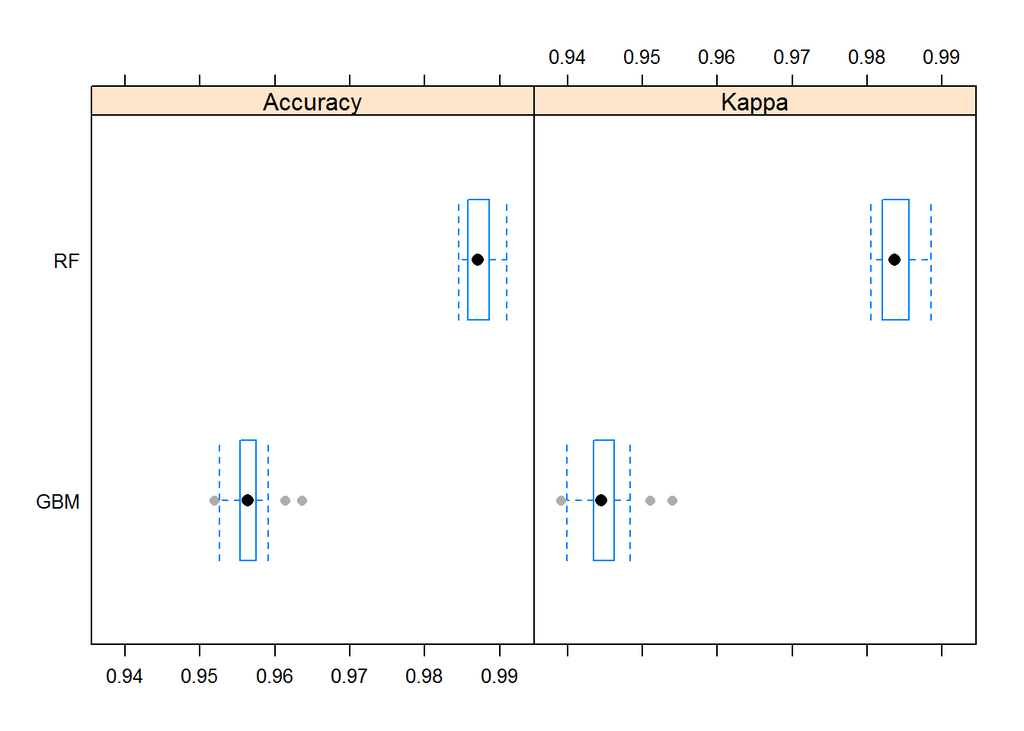

```r
resamps <- resamples(list(RF = modelrf, GBM = modelgbm))
theme1 <- trellis.par.get()
theme1$plot.symbol$col = rgb(.2, .2, .2, .4)
theme1$plot.symbol$pch = 16
theme1$plot.line$col = rgb(1, 0, 0, .7)
theme1$plot.line$lwd <- 2
trellis.par.set(theme1)
bwplot(resamps, layout = c(2, 1))
```

The boxplot graph confirms that the Random Forest model is the best fit. We’ve added in the annexes some more details about that model.

Furthermore, with such a low out of sample error rate (or high accuracy rate), we do not see the point in further tuning the model.

## Predictions on testdata

We can now run our model on testdata.

```r
predictiontest <- predict(modelrf, testdata)
predictiontest
```

```
##  [1] B A B A A E D B A A B C B A E E A B B B
## Levels: A B C D E
```

## Appendix 1

```r
modelrf$finalModel
```

```
##
## Call:
##  randomForest(x = x, y = y, mtry = param$mtry)
##                Type of random forest: classification
##                      Number of trees: 500
## No. of variables tried at each split: 27
##
##         OOB estimate of  error rate: 0.9%
## Confusion matrix:
##      A    B    C    D    E class.error
## A 3342    4    1    0    1 0.001792115
## B   19 2253    7    0    0 0.011408513
## C    0   19 2027    8    0 0.013145083
## D    0    0   27 1900    3 0.015544041
## E    0    2    6    9 2148 0.007852194
```

## Appendix 2

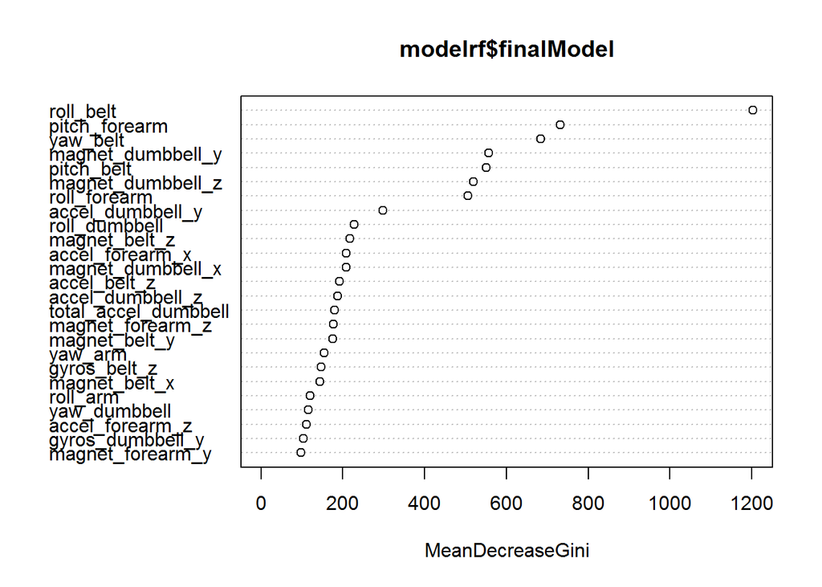

```r
# The graph shows the top 25 most important predictors.
varImpPlot(modelrf$finalModel, n.var = 25)
```

## Appendix 3

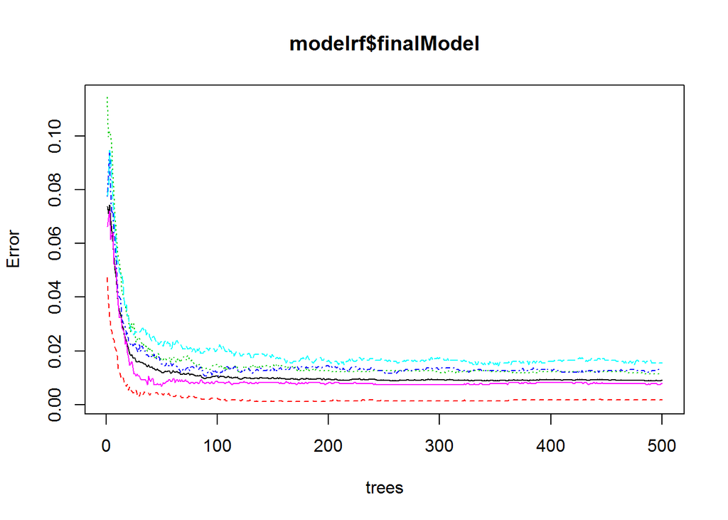

```r
plot(modelrf$finalModel)
```